# Example 7.1 Random effects model

Yanming Di

2018-05-17

Example. Measurements of lipids in replicate serum samples run on four machines on each of four days (Kuehl, p. 233). Because the four machines can be thought of as a random sample from a larger population of machines, and because we are not interested in drawing conclusions about the specific machines chosen, machine can be thought of as a random effect. Similarly, it makes sense to model day as a random effect.

Our goal will to be to assess the amount of variability in lipid measurements that can be attributed to machine and to day.

## Load the lipids data

```r
df = read.table("../data/EXPL7-1.txt", header=TRUE);
str(df);
```

```
## 'data.frame':    32 obs. of  3 variables:
##  $ DAY    : int  1 1 1 1 1 1 1 1 2 2 ...
##  $ MACHINE: int  1 1 2 2 3 3 4 4 1 1 ...
##  $ TRIGLY : num  142 144 149 147 143 ...
```

```r
head(df);
```

```
##   DAY MACHINE TRIGLY
## 1   1       1  142.3
## 2   1       1  144.0
## 3   1       2  148.6
## 4   1       2  146.9
## 5   1       3  142.9
## 6   1       3  147.4
```

```r
day = factor(df$DAY);
machine = factor(df$MACHINE)
trigly = df$TRIGLY;
```

## Plot the data

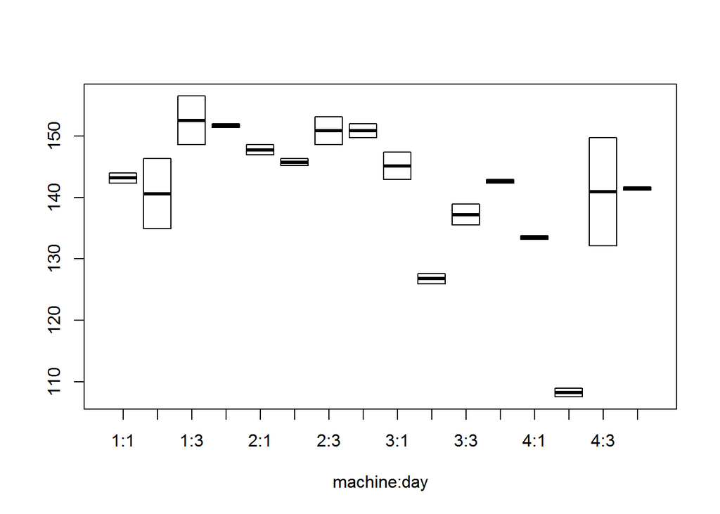

```r
f = machine:day;
boxplot(trigly ~ f, xlab="machine:day");
```

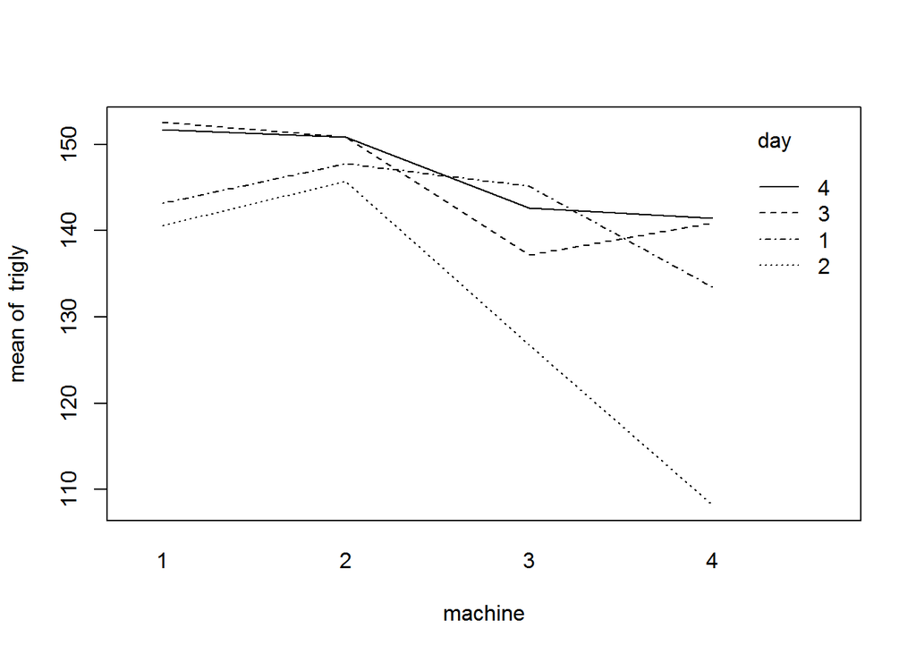

```r
interaction.plot(machine, day, trigly);
```

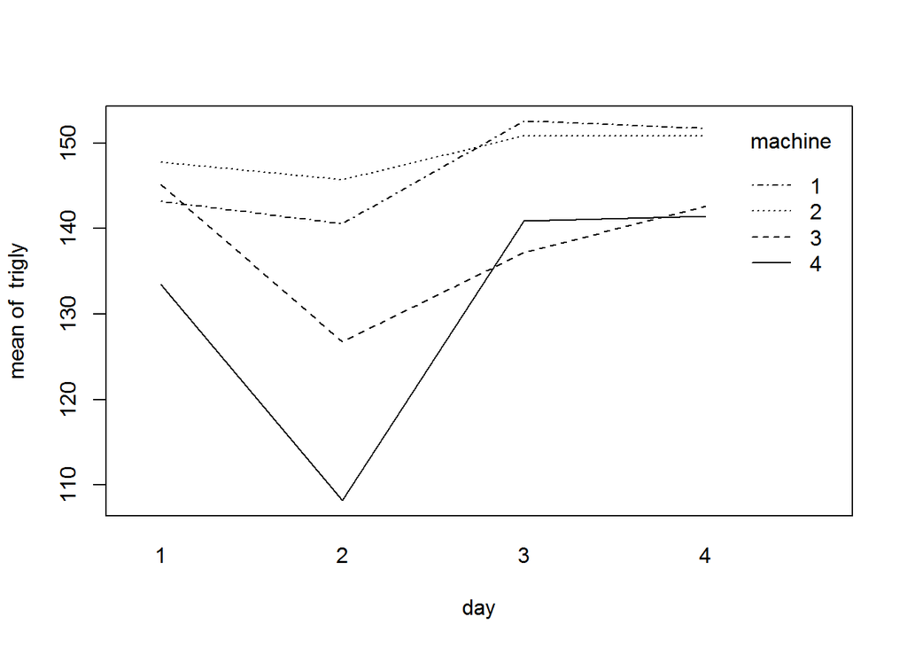

```r
interaction.plot(day, machine, trigly);
```

From the plots, we see that there is interaction between machine effect and day effect.

## Fit the ANOVA model

```r
m = lm(trigly ~ day*machine);
anova(m);
```

```
## Analysis of Variance Table
##
## Response: trigly
##             Df  Sum Sq Mean Sq F value    Pr(>F)
## day          3 1334.46  444.82 24.8569 2.907e-06 ***
## machine      3 1647.28  549.09 30.6836 7.192e-07 ***
## day:machine  9  786.04   87.34  4.8805  0.002936 **
## Residuals   16  286.33   17.90
## ---
## Signif. codes:  0 '***' 0.001 '**' 0.01 '*' 0.05 '.' 0.1 ' ' 1
```

## Expected values of the mean squares

Read page 51-52 of the notes (page 235 of Kuehl)

Suppose we have two factors A (with a levels) and B (with b levels), and both factors are considered random effects. The expected value of the MSE is given below:

| Source of Variation | d.f. | MS | Expected Mean Squares |
| --- | --- | --- | --- |
| A | a - 1 | MSA | $\sigma^2 +r \sigma^2_{ab} + br\sigma^2_{a}$ |
| B | b - 1 | MSB | $\sigma^2 +r \sigma^2_{ab} + ar\sigma^2_{b}$ |
| AB | (a - 1)(b - 1) | MSAB | $\sigma^2 +r \sigma^2_{ab}$ |
| Error | ab(r-1) | MSE | $\sigma^2$ |

## Estimating variance components

```r
a = b = 4;
r = 2;

## Extract mean square values from the ANOVA output
anova.m = anova(m);
ms = anova.m$"Mean Sq";

## Extract df from the ANOVA table
df = anova.m$Df;

## Round the ms values to the 1/100th (I do this for the table dispaly below. This is not necessarily needed in practice.)
ms = round(ms, 2)
```

| Source of Variation | d.f. | MS | Expected Mean Squares |
| --- | --- | --- | --- |
| A (day) | 3 | 444.82 | $\sigma^2 +r \sigma^2_{ab} + br\sigma^2_{a}$ |
| B (machine) | 3 | 549.09 | $\sigma^2 +r \sigma^2_{ab} + ar\sigma^2_{b}$ |
| AB (day $\times$ machine) | 9 | 87.34 | $\sigma^2 +r \sigma^2_{ab}$ |
| Error | 16 | 17.9 | $\sigma^2$ |

Some algebra shows that the following estimators have the desired expected values:
$$\hat \sigma^2_a = \dfrac{MSA - MSAB}{br} = \dfrac{444.82 - 87.34}{4 \times 2} = 44.685.$$
$$\hat \sigma^2_b = \dfrac{MSA - MSAB}{ar} = \dfrac{549.09 - 87.34}{4 \times 2} = 57.71875.$$
$$\hat \sigma^2_{ab} = \dfrac{MSAB - MSE}{r} = \dfrac{87.34 - 17.9}{2} = 34.72.$$
$$\hat \sigma^2 = MSE = 17.9.$$

## Tests for the random effects

For random effects models, we can still use a F-test to test whether certain main or interaction effect is significant, but there are two aspects that differ from the fixed effects models:

1. The null hypothesis is slightly different from the fixed-effect model case. For a random effects model, to say that a factor has no effect is equivalent to say that the corresponding variance component is $0$. (What is null hypothesis when we test a main effect in a fixed-effect model?)
2. We have to perform the F-tests **by hand**, since the F-tests from the standard ANOVA asumes fixed effects, and thus may not use the correct the denominators.

The choice of the numerator of the F-test is often “obvious”, when choosing the denominator, it has to have the same expected value as the numberator **under the null hypothesis**.

### Example 1

To test no day effect, the null hypothesis is $H_0: \sigma_a^2=0$, we should use
$$F_0 = MSA/MSAB$$
as the test statistic. Note that here the denominator is $MSAB$ not $MSE$. To compute the $p$-value, we compare $F_0$ to $F_{a-1, (a-1)(b-1)}$ (we can read the d.f. from the ANOVA table).

```r
## F-statistic and p-value for no day effect. Remember that in the ANoVA table we fit earlier, row 1 corresponds to day, row 3 corresponds to interaction).
f = ms[1]/ms[3];
p = pf(f, df[1], df[3], lower.tail=FALSE);
```

$F_0 = 444.82/87.34 = 5.09297$ and p-value is $pf(F_0, 3, 9) =0.0248042$.

Exercise: perform the test for no machine effect.

### Example 2

To test no interaction effect, the null hypothesis is $H_0: \sigma_{ab}^2 = 0$, we should
$$F_0 = MSAB/MSE$$
as the statistic and compare it to $F_{(a-1)(b-1), ab(r-1)}$ (we can read the d.f. from the ANOVA table).

```r
## F-statistic and p-value for no interaction effect.
f = ms[3]/ms[4];
p = pf(f, df[3], df[4],lower.tail=FALSE);
```

$F_0 = 87.34/17.9 = 4.8793296$ and p-value is $pf(F_0, 9, 16) =0.0029392$.